# ISLR chap6.5.

# 6.5.1 subset selection

```r
library(ISLR2)
#View(Hitters)
names(Hitters)
```

```
 [1] "AtBat"     "Hits"      "HmRun"     "Runs"      "RBI"       "Walks"     "Years"     "CAtBat"    "CHits"     "CHmRun"    "CRuns"
[12] "CRBI"      "CWalks"    "League"    "Division"  "PutOuts"   "Assists"   "Errors"    "Salary"    "NewLeague"
```

```r
dim(Hitters)
```

```
[1] 322  20
```

```r
sum(is.na(Hitters$Salary))
```

```
[1] 59
```

disregarding entries with no salary:

```r
Hitters2 <- na.omit(Hitters)
dim(Hitters2)
```

```
[1] 263  20
```

subset selection using the `leaps` library:

```r
library(leaps)
regfit.full <- regsubsets(Salary ~ ., Hitters2)
summary(regfit.full)
```

let’s increase the number of variables (default maxes out at 8 it seems):

```r
regfit.full2 <- regsubsets(Salary ~ ., data = Hitters2, nvmax = 19)
reg.summary <- summary(regfit.full2)
reg.summary
```

```
Subset selection object
Call: regsubsets.formula(Salary ~ ., data = Hitters2, nvmax = 19)
19 Variables  (and intercept)
           Forced in Forced out
AtBat          FALSE      FALSE
Hits           FALSE      FALSE
HmRun          FALSE      FALSE
Runs           FALSE      FALSE
RBI            FALSE      FALSE
Walks          FALSE      FALSE
Years          FALSE      FALSE
CAtBat         FALSE      FALSE
CHits          FALSE      FALSE
CHmRun         FALSE      FALSE
CRuns          FALSE      FALSE
CRBI           FALSE      FALSE
CWalks         FALSE      FALSE
LeagueN        FALSE      FALSE
DivisionW      FALSE      FALSE
PutOuts        FALSE      FALSE
Assists        FALSE      FALSE
Errors         FALSE      FALSE
NewLeagueN     FALSE      FALSE
1 subsets of each size up to 19
Selection Algorithm: exhaustive
          AtBat Hits HmRun Runs RBI Walks Years CAtBat CHits CHmRun CRuns CRBI CWalks LeagueN DivisionW PutOuts Assists Errors NewLeagueN
1  ( 1 )  " "   " "  " "   " "  " " " "   " "   " "    " "   " "    " "   "*"  " "    " "     " "       " "     " "     " "    " "
2  ( 1 )  " "   "*"  " "   " "  " " " "   " "   " "    " "   " "    " "   "*"  " "    " "     " "       " "     " "     " "    " "
3  ( 1 )  " "   "*"  " "   " "  " " " "   " "   " "    " "   " "    " "   "*"  " "    " "     " "       "*"     " "     " "    " "
4  ( 1 )  " "   "*"  " "   " "  " " " "   " "   " "    " "   " "    " "   "*"  " "    " "     "*"       "*"     " "     " "    " "
5  ( 1 )  "*"   "*"  " "   " "  " " " "   " "   " "    " "   " "    " "   "*"  " "    " "     "*"       "*"     " "     " "    " "
6  ( 1 )  "*"   "*"  " "   " "  " " "*"   " "   " "    " "   " "    " "   "*"  " "    " "     "*"       "*"     " "     " "    " "
7  ( 1 )  " "   "*"  " "   " "  " " "*"   " "   "*"    "*"   "*"    " "   " "  " "    " "     "*"       "*"     " "     " "    " "
8  ( 1 )  "*"   "*"  " "   " "  " " "*"   " "   " "    " "   "*"    "*"   " "  "*"    " "     "*"       "*"     " "     " "    " "
9  ( 1 )  "*"   "*"  " "   " "  " " "*"   " "   "*"    " "   " "    "*"   "*"  "*"    " "     "*"       "*"     " "     " "    " "
10  ( 1 ) "*"   "*"  " "   " "  " " "*"   " "   "*"    " "   " "    "*"   "*"  "*"    " "     "*"       "*"     "*"     " "    " "
11  ( 1 ) "*"   "*"  " "   " "  " " "*"   " "   "*"    " "   " "    "*"   "*"  "*"    "*"     "*"       "*"     "*"     " "    " "
12  ( 1 ) "*"   "*"  " "   "*"  " " "*"   " "   "*"    " "   " "    "*"   "*"  "*"    "*"     "*"       "*"     "*"     " "    " "
13  ( 1 ) "*"   "*"  " "   "*"  " " "*"   " "   "*"    " "   " "    "*"   "*"  "*"    "*"     "*"       "*"     "*"     "*"    " "
14  ( 1 ) "*"   "*"  "*"   "*"  " " "*"   " "   "*"    " "   " "    "*"   "*"  "*"    "*"     "*"       "*"     "*"     "*"    " "
15  ( 1 ) "*"   "*"  "*"   "*"  " " "*"   " "   "*"    "*"   " "    "*"   "*"  "*"    "*"     "*"       "*"     "*"     "*"    " "
16  ( 1 ) "*"   "*"  "*"   "*"  "*" "*"   " "   "*"    "*"   " "    "*"   "*"  "*"    "*"     "*"       "*"     "*"     "*"    " "
17  ( 1 ) "*"   "*"  "*"   "*"  "*" "*"   " "   "*"    "*"   " "    "*"   "*"  "*"    "*"     "*"       "*"     "*"     "*"    "*"
18  ( 1 ) "*"   "*"  "*"   "*"  "*" "*"   "*"   "*"    "*"   " "    "*"   "*"  "*"    "*"     "*"       "*"     "*"     "*"    "*"
19  ( 1 ) "*"   "*"  "*"   "*"  "*" "*"   "*"   "*"    "*"   "*"    "*"   "*"  "*"    "*"     "*"       "*"     "*"     "*"    "*"
```

```r
names(reg.summary)
reg.summary$rsq
```

time for some plots!

```r
par(mfrow = c(2, 2))
plot(reg.summary$rss, xlab = "Number of Variables", ylab = "RSS", type = "l")
plot(reg.summary$adjr2, xlab = "Number of Variables", ylab = "Adjusted RSq", type = "l")
which.max(reg.summary$adjr2)
points(11, reg.summary$adjr2[11], col = "red", cex = 2, pch = 20)
```

[output not shown]

for the other adjustments (it’s pretty cool, they’re calculated up front by `leaps`):

```r
plot(reg.summary$cp, xlab = "Number of Variables", ylab = "Cp", type = "l")
which.min(reg.summary$cp)
points(10, reg.summary$cp[10], col = "red", cex = 2, pch = 20)
which.min(reg.summary$bic)
plot(reg.summary$bic, xlab = "Number of Variables", ylab = "BIC", type = "l")
points(6, reg.summary$bic[6], col = "red", cex = 2, pch = 20)
```

[output not shown]

all ’em plots!

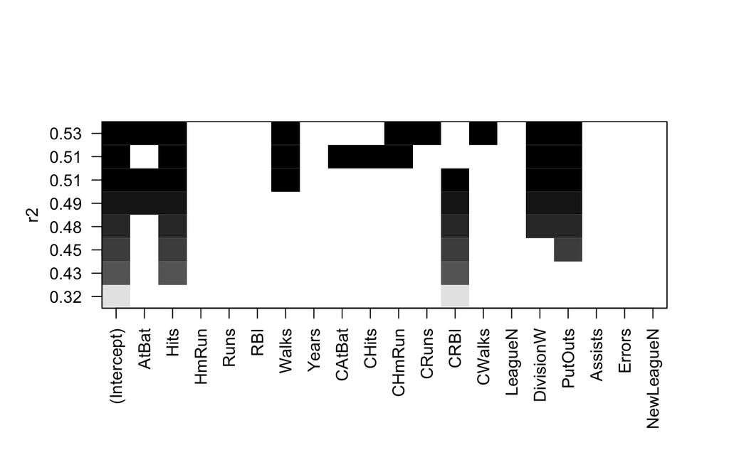

```r
plot(regfit.full, scale = "r2")
```

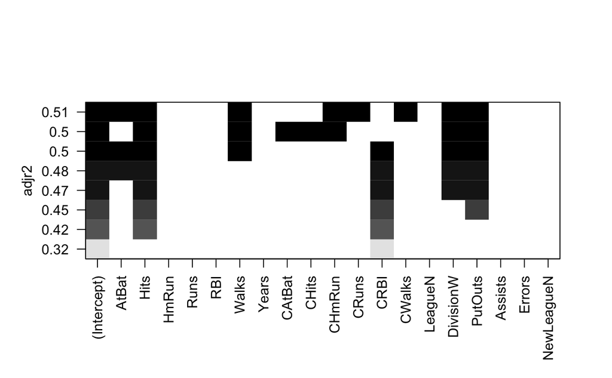

```r
plot(regfit.full, scale = "adjr2")
```

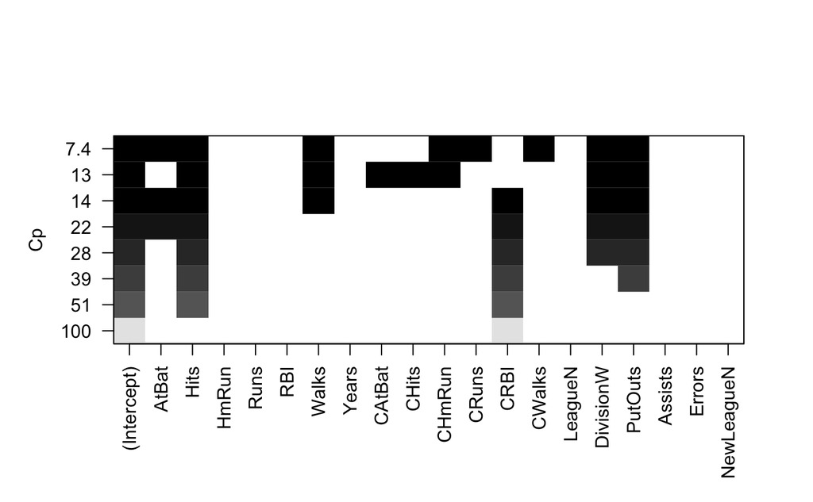

```r
plot(regfit.full, scale = "Cp")
```

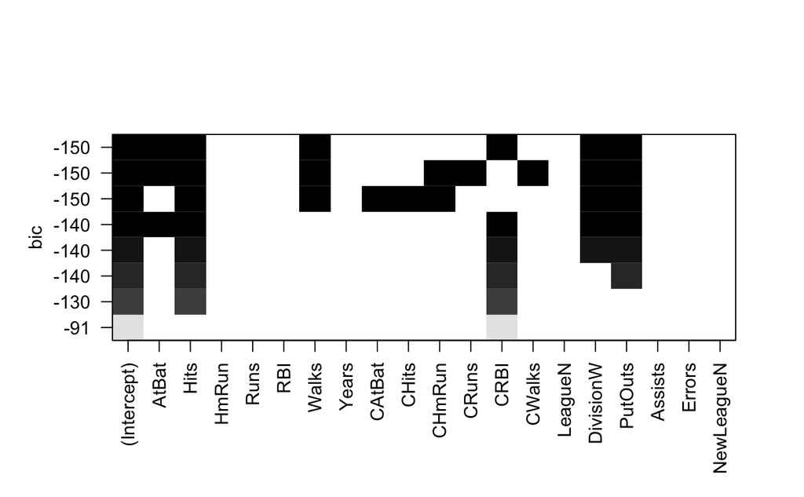

```r
plot(regfit.full, scale = "bic")
```

step-wise selection:

```r
coef(regfit.full, 6)
regfit.fwd <- regsubsets(Salary ~ ., data = Hitters2, nvmax = 19, method = "forward")
summary(regfit.fwd)
regfit.bwd <- regsubsets(Salary ~ ., data = Hitters2, nvmax = 19, method = "backward")
summary(regfit.bwd)
```

```r
coef(regfit.full, 7)
coef(regfit.fwd, 7)
coef(regfit.bwd, 7)
```

let’s do this using CV:

```r
set.seed(1)
train <- sample(c(TRUE, FALSE), nrow(Hitters2),
replace = TRUE)
test <- (!train)
regfit.best <- regsubsets(Salary ~ ., data = Hitters2[train, ], nvmax = 19)
test.mat <- model.matrix(Salary ~ ., data = Hitters2[test, ])
```

find the number of variables in the best model:

```r
val.errors <- rep(NA, 19)
for (i in 1:19) {
coefi <- coef(regfit.best, id = i)
pred <- test.mat[, names(coefi)] %*% coefi
val.errors[i] <- mean((Hitters2$Salary[test] - pred)^2)
}
which.min(val.errors)
coef(regfit.best, which.min(val.errors))
```

making it a fn:

```r
predict.regsubsets <- function(object, newdata, id, ...) {
form <- as.formula(object$call[[2]])
mat <- model.matrix(form, newdata)
coefi <- coef(object, id = id)
xvars <- names(coefi)
mat[, xvars] %*% coefi
}
regfit.best <- regsubsets(Salary ~ ., data = Hitters2, nvmax = 19)
coef(regfit.best, 7)
```

using it for $k$-folds

```r
k <- 10
n <- nrow(Hitters2)
set.seed(1)
folds <- sample(rep(1:k, length = n))
cv.errors <- matrix(NA, k, 19,
dimnames = list(NULL, paste(1:19)))
```

```r
for (j in 1:k) {
best.fit <- regsubsets(Salary ~ .,data = Hitters2[folds != j, ],nvmax = 19)
for (i in 1:19) {
pred <- predict(best.fit, Hitters2[folds == j, ], id = i)
cv.errors[j, i] <- mean((Hitters2$Salary[folds == j] - pred)^2)
}
}
```

```r
mean.cv.errors <- apply(cv.errors, 2, mean)
mean.cv.errors
par(mfrow = c(1, 1))
plot(mean.cv.errors, type = "b")
```

```r
reg.best <- regsubsets(Salary ~ ., data = Hitters2, nvmax = 19)
coef(reg.best, 10)
```

# 6.5.2 Ridge Regression and the Lasso

## Ridge Regression first

Small transform due to how `glmnet` takes its inputs:

```r
x <- model.matrix(Salary ~ ., Hitters2)[, -1]
y <- Hitters2$Salary
```

by default vars are standardised (remember Ridge isn’t scale equivariant)

```r
library(glmnet)
grid <- 10^seq(10, -2, length = 100)
ridge.mod <- glmnet(x, y, alpha = 0, lambda = grid)
```

```r
dim(coef(ridge.mod))
doit <- function(idx) {
  print(ridge.mod$lambda[idx])
  print(coef(ridge.mod)[, idx])
  # l2
  sqrt(sum(coef(ridge.mod)[-1, idx]^2))
}

# 0 is the null model?
doit(1)
doit(50)
```

predict for a new value of $\lambda$:

```r
predict(ridge.mod, s = 50, type ="coefficients")[1:20, ]
```

we expect those values to be between of indicies 69 and 70 on our grid:

```r
ridge.mod$lambda[69]
ridge.mod$lambda[70]
```

let’s estimate the test error:

```r
set.seed(1)
train <- sample(1:nrow(x), nrow(x) / 2)
test <- (-train)
y.test <- y[test]
```

now to evaluate the MSE on the test set using $\lambda=4$:

```r
# use the training set to build the model
ridge.mod <- glmnet(x[train, ], y[train], alpha = 0, lambda = grid, thresh = 1e-12)
# use predict
ridge.pred <- predict(ridge.mod, s = 4, newx = x[test, ])
mean((ridge.pred - y.test)^2)
```

```
[1] 142199.2
```

using a model with only the intercept, we predict the mean for each value and compute the MSE as such:

```r
mean((mean(y[train]) - y.test)^2)
```

```
[1] 224669.9
```

```r
ridge.pred <- predict(ridge.mod, s = 0, newx = x[test, ], exact = T, x = x[train, ], y = y[train])
mean((ridge.pred - y.test)^2)
lm(y ~ x, subset = train)
predict(ridge.mod, s = 0, exact = T, type = "coefficients",
x = x[train, ], y = y[train])[1:20, ]
```

to choose the best $\lambda$, we can use cross-validation.

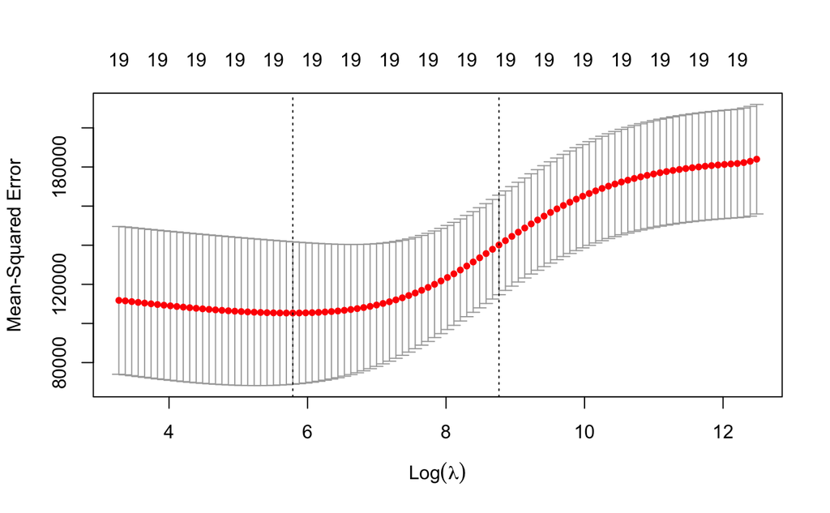

```r
set.seed(1)
cv.out <- cv.glmnet(x[train, ], y[train], alpha = 0)
plot(cv.out)
```

```r
bestlam <- cv.out$lambda.min
bestlam
```

```
[1] 326.0828
```

corresponding MSE on our *test* sample is:

```r
ridge.pred <- predict(ridge.mod, s = bestlam, newx = x[test, ])
mean((ridge.pred - y.test)^2)
```

refit on the whole data, none of the coefs are zero - no variable selection (expeced, *ridge regression* doesn’t do that):

```r
out <- glmnet(x, y, alpha = 0)
predict(out, type = "coefficients", s = bestlam)[1:20, ]
```

## Now for the Lasso

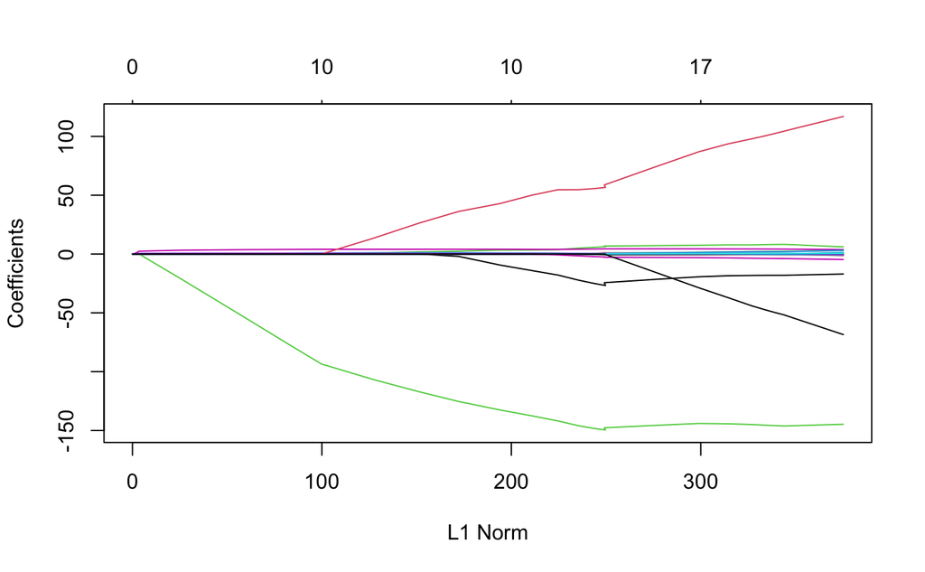

```r
library(glmnet)
lasso.mod <- glmnet(x[train, ], y[train], alpha = 1, lambda = grid)
plot(lasso.mod)
```

why are we plotting coeffs vs L1 norm??

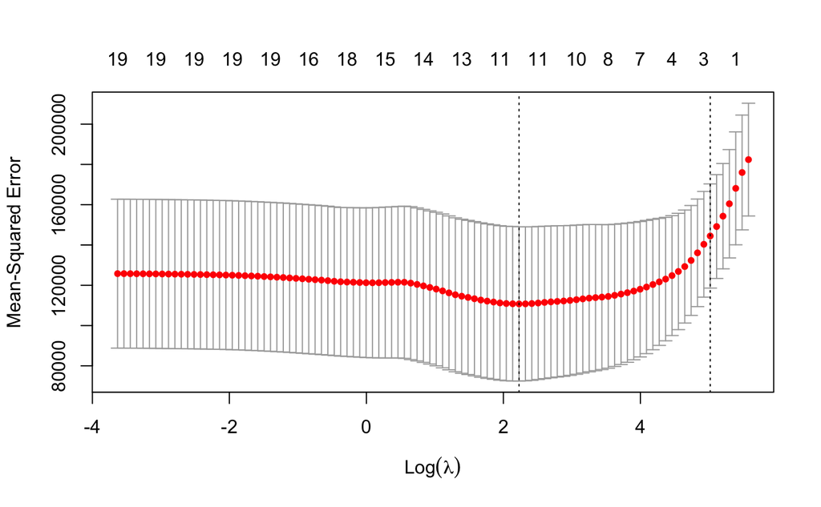

```r
set.seed(1)
cv.out <- cv.glmnet(x[train, ], y[train], alpha = 1)
plot(cv.out)
```

```r
bestlam <- cv.out$lambda.min
lasso.pred <- predict(lasso.mod, s = bestlam,newx = x[test, ])
mean((lasso.pred - y.test)^2)
```

```
[1] 143673.6
```

?

```r
out <- glmnet(x, y, alpha = 1, lambda = grid)
lasso.coef <- predict(out, type = "coefficients", s = bestlam)[1:20, ]
lasso.coef
```

```
  (Intercept)         AtBat          Hits         HmRun          Runs           RBI         Walks         Years
   1.27479059   -0.05497143    2.18034583    0.00000000    0.00000000    0.00000000    2.29192406   -0.33806109
       CAtBat         CHits        CHmRun         CRuns          CRBI        CWalks       LeagueN     DivisionW
   0.00000000    0.00000000    0.02825013    0.21628385    0.41712537    0.00000000   20.28615023 -116.16755870
      PutOuts       Assists        Errors    NewLeagueN
   0.23752385    0.00000000   -0.85629148    0.00000000
```

```r
lasso.coef[lasso.coef != 0]
```

```
  (Intercept)         AtBat          Hits         Walks         Years        CHmRun         CRuns          CRBI
   1.27479059   -0.05497143    2.18034583    2.29192406   -0.33806109    0.02825013    0.21628385    0.41712537
      LeagueN     DivisionW       PutOuts        Errors
  20.28615023 -116.16755870    0.23752385   -0.85629148
```

### 6.5.3

```r
library(pls)
library(ISLR2)
set.seed(2)
pcr.fit <- pcr(Salary ~ ., data = Hitters2, scale = TRUE, validation = "CV")
summary(pcr.fit)
```

```
Data:   X dimension: 263 19
    Y dimension: 263 1
Fit method: svdpc
Number of components considered: 19

VALIDATION: RMSEP
Cross-validated using 10 random segments.
       (Intercept)  1 comps  2 comps  3 comps  4 comps  5 comps  6 comps  7 comps  8 comps  9 comps  10 comps  11 comps
CV             452    351.9    353.2    355.0    352.8    348.4    343.6    345.5    347.7    349.6     351.4     352.1
adjCV          452    351.6    352.7    354.4    352.1    347.6    342.7    344.7    346.7    348.5     350.1     350.7
       12 comps  13 comps  14 comps  15 comps  16 comps  17 comps  18 comps  19 comps
CV        353.5     358.2     349.7     349.4     339.9     341.6     339.2     339.6
adjCV     352.0     356.5     348.0     347.7     338.2     339.7     337.2     337.6

TRAINING: % variance explained
        1 comps  2 comps  3 comps  4 comps  5 comps  6 comps  7 comps  8 comps  9 comps  10 comps  11 comps  12 comps
X         38.31    60.16    70.84    79.03    84.29    88.63    92.26    94.96    96.28     97.26     97.98     98.65
Salary    40.63    41.58    42.17    43.22    44.90    46.48    46.69    46.75    46.86     47.76     47.82     47.85
        13 comps  14 comps  15 comps  16 comps  17 comps  18 comps  19 comps
X          99.15     99.47     99.75     99.89     99.97     99.99    100.00
Salary     48.10     50.40     50.55     53.01     53.85     54.61     54.61
```

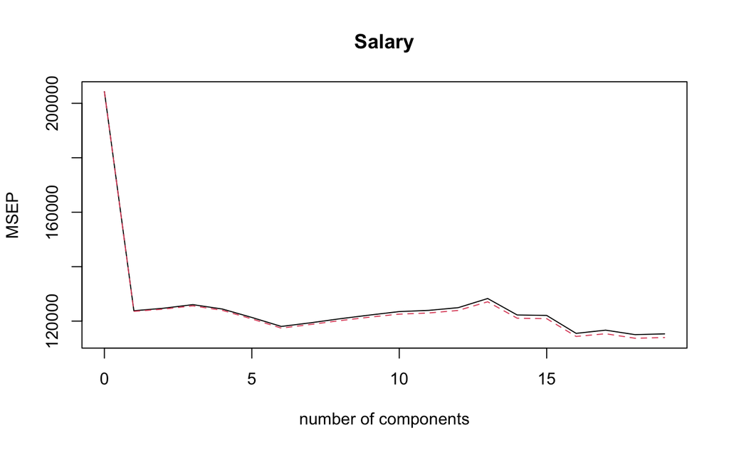

```r
validationplot(pcr.fit, val.type = "MSEP")
```

evaluate perf on the training data:

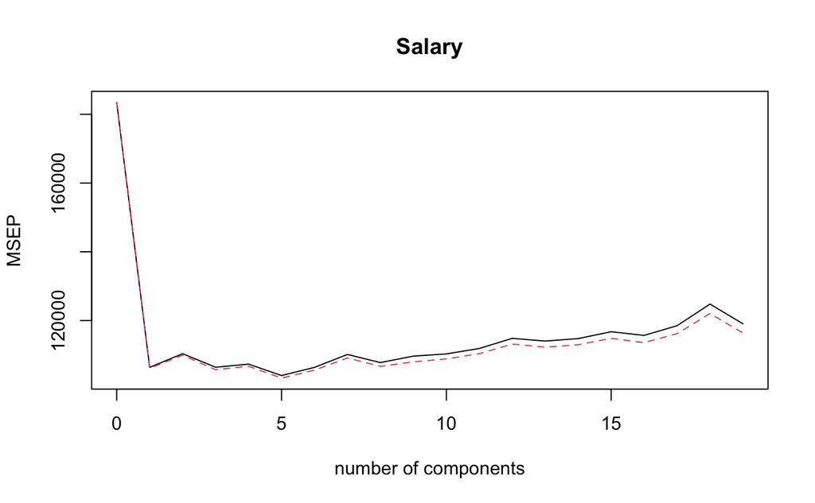

```r
set.seed(1)
pcr.fit <- pcr(Salary ~ ., data = Hitters2, subset = train, scale = TRUE , validation = "CV")
validationplot(pcr.fit, val.type = "MSEP")
```

we can find the `ncomp` with the lowest CV using `min(MSEP(pcr.fit)$val)`

calculate MSE:

```r
pcr.pred <- predict(pcr.fit, x[test, ], ncomp = 5)
mean((pcr.pred - y.test)^2)
```

```
[1] 142811.8
```

fit on the whole data:

```r
pcr.fit <- pcr(y ~ x, scale = TRUE, ncomp = 5)
summary(pcr.fit)
```

#### Partial Least Square

```r
set.seed(1)
pls.fit <- plsr(Salary ~ ., data = Hitters2, subset = train, scale= TRUE , validation = "CV")
summary(pls.fit)
```

```
Data:   X dimension: 131 19
    Y dimension: 131 1
Fit method: kernelpls
Number of components considered: 19

VALIDATION: RMSEP
Cross-validated using 10 random segments.
       (Intercept)  1 comps  2 comps  3 comps  4 comps  5 comps  6 comps  7 comps  8 comps  9 comps  10 comps  11 comps
CV           428.3    325.5    329.9    328.8    339.0    338.9    340.1    339.0    347.1    346.4     343.4     341.5
adjCV        428.3    325.0    328.2    327.2    336.6    336.1    336.6    336.2    343.4    342.8     340.2     338.3
       12 comps  13 comps  14 comps  15 comps  16 comps  17 comps  18 comps  19 comps
CV        345.4     356.4     348.4     349.1     350.0     344.2     344.5     345.0
adjCV     341.8     351.1     344.2     345.0     345.9     340.4     340.6     341.1

TRAINING: % variance explained
        1 comps  2 comps  3 comps  4 comps  5 comps  6 comps  7 comps  8 comps  9 comps  10 comps  11 comps  12 comps
X         39.13    48.80    60.09    75.07    78.58    81.12    88.21    90.71    93.17     96.05     97.08     97.61
Salary    46.36    50.72    52.23    53.03    54.07    54.77    55.05    55.66    55.95     56.12     56.47     56.68
        13 comps  14 comps  15 comps  16 comps  17 comps  18 comps  19 comps
X          97.97     98.70     99.12     99.61     99.70     99.95    100.00
Salary     57.37     57.76     58.08     58.17     58.49     58.56     58.62
```

plot!

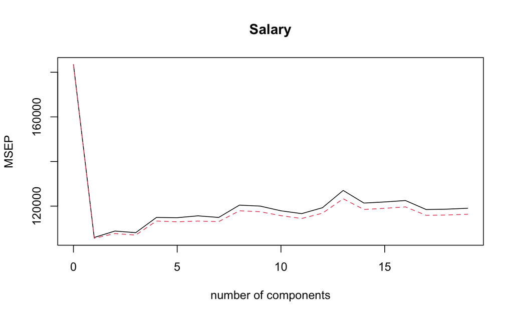

```r
validationplot(pls.fit, val.type = "MSEP")
```

Err - best with only 1 component!

```r
pls.pred <- predict(pls.fit, x[test, ], ncomp = 1)
mean((pls.pred - y.test)^2)
```

```
[1] 151995.3
```

```r
pls.fit <- plsr(Salary ~ ., data = Hitters2, scale = TRUE, ncomp = 1)
summary(pls.fit)
```

```
Data:   X dimension: 263 19
    Y dimension: 263 1
Fit method: kernelpls
Number of components considered: 1
TRAINING: % variance explained
        1 comps
X         38.08
Salary    43.05
```